# Examen 2025

Manuel Berea Arellano

2025-03-16

## 1. Modelo de regresión simple

### 1.1 Lectura de datos y estadísticas descriptivas

- freeny.y es un vector serie temporal de datos trimestrales de ventas que van desde (1962,2Q) to (1971,4Q).
- freeny.x es una matriz de variables explicativas. La primera columna es freeny.y retrasada un trimestre, la segunda un indice de precios (price index), la tercera el nivel de renta (income level), y un indicador del mercado potencial (market potential).

Se pide leer la base de datos freeny, obtener un sumario de estadísticas, presentar los primeros y últimos resultados, y las matrices de varianzas y correlación.

Podemos ver un resumen del dataframe con la función skim, que nos da pequeño sumario de numero de filas, columnas. El tipo de variables explicativas que tenemos, y un resumen de algunos estadisticos como la media, desviación estandar, mediana, minimo, maximo, etc.

Además, para la variable y, al ser un vector temporal obtenemos algunos otra información.

```r
skim(freeny)
```

Data summary

| Name | freeny |
| --- | --- |
| Number of rows | 39 |
| Number of columns | 5 |
| _______________________ |  |
| Column type frequency: |  |
| numeric | 4 |
| ts | 1 |
| ________________________ |  |
| Group variables | None |

**Variable type: numeric**

| skim_variable | n_missing | complete_rate | mean | sd | p0 | p25 | p50 | p75 | p100 | hist |
| --- | --- | --- | --- | --- | --- | --- | --- | --- | --- | --- |
| lag.quarterly.revenue | 0 | 1 | 9.28 | 0.32 | 8.79 | 9.02 | 9.28 | 9.56 | 9.78 | ▇▆▆▅▇ |
| price.index | 0 | 1 | 4.50 | 0.13 | 4.28 | 4.39 | 4.51 | 4.60 | 4.71 | ▅▅▂▇▃ |
| income.level | 0 | 1 | 6.04 | 0.12 | 5.82 | 5.95 | 6.06 | 6.14 | 6.20 | ▅▃▃▇▇ |
| market.potential | 0 | 1 | 13.07 | 0.06 | 12.97 | 13.01 | 13.07 | 13.12 | 13.17 | ▇▅▆▆▇ |

**Variable type: ts**

| skim_variable | n_missing | complete_rate | start | end | frequency | deltat | mean | sd | min | max | median | line_graph |
| --- | --- | --- | --- | --- | --- | --- | --- | --- | --- | --- | --- | --- |
| y | 0 | 1 | 1962 | 1971 | 4 | 0.25 | 9.31 | 0.32 | 8.79 | 9.79 | 9.31 | ⣀⣀⠤⠤⠒⠒⠉⠉ |

Para ver los primeros y ultimos resultados podemos utilizar la funcion head y tail.

```r
head(freeny)
```

```
##               y lag.quarterly.revenue price.index income.level market.potential
## 1962.25 8.79236               8.79636     4.70997      5.82110          12.9699
## 1962.5  8.79137               8.79236     4.70217      5.82558          12.9733
## 1962.75 8.81486               8.79137     4.68944      5.83112          12.9774
## 1963    8.81301               8.81486     4.68558      5.84046          12.9806
## 1963.25 8.90751               8.81301     4.64019      5.85036          12.9831
## 1963.5  8.93673               8.90751     4.62553      5.86464          12.9854
```

```r
tail(freeny)
```

```
##               y lag.quarterly.revenue price.index income.level market.potential
## 1970.5  9.69958               9.69405     4.30909      6.17369          13.1459
## 1970.75 9.68683               9.69958     4.30909      6.16135          13.1520
## 1971    9.71774               9.68683     4.30552      6.18231          13.1593
## 1971.25 9.74924               9.71774     4.29627      6.18768          13.1579
## 1971.5  9.77536               9.74924     4.27839      6.19377          13.1625
## 1971.75 9.79424               9.77536     4.27789      6.20030          13.1664
```

Para los ultimos registros, a primera vista no se aprecia nada extraño.

Para ver las matrices de varianzas/covariancias y correlación, podemos utilizar las funciones var y cor.

En la siguiente tabla encontramos, la matriz de variancias/covarianzas, en la diagonal contramos las variancias de cada variable, y en las otras celdas las covarianzas entre las variables. Una varianza baja, implica que la variabilidad es baja, es decir, que los valores de la variable no se alejan mucho de la media. Una covarianza alta, implica que las variables están relacionadas, es decir, que si una variable aumenta, la otra también lo hace. Y una covarianza negativa, signigica que cuando una variable aumenta, la otra disminuye.

```r
cov(freeny)
```

```
##                                 y lag.quarterly.revenue  price.index
## y                      0.09961393            0.09934735 -0.041648220
## lag.quarterly.revenue  0.09934735            0.09951998 -0.041624602
## price.index           -0.04164822           -0.04162460  0.017784056
## income.level           0.03740331            0.03729911 -0.015321080
## market.potential       0.02028916            0.02029208 -0.008508181
##                       income.level market.potential
## y                      0.037403313      0.020289157
## lag.quarterly.revenue  0.037299113      0.020292084
## price.index           -0.015321080     -0.008508181
## income.level           0.014506558      0.007586505
## market.potential       0.007586505      0.004160757
```

Ahora, analicemos la correlación de las variables. La correlación es un valor que va de -1 a 1, donde 1 significa que las variables están perfectamente correlacionadas positivamente, -1 perfectamente correlacionadas negativamente, y 0 no hay correlación. En la diagonal siempre encontraremos 1 y es una matriz simétrica. Podemos ver como todas las variables tienen correlación cercana a 1 o -1, lo que significa que linealmente están muy relacionadas.

```r
cor(freeny)
```

```
##                                y lag.quarterly.revenue price.index income.level
## y                      1.0000000             0.9977945  -0.9895118    0.9839382
## lag.quarterly.revenue  0.9977945             1.0000000  -0.9894174    0.9816602
## price.index           -0.9895118            -0.9894174   1.0000000   -0.9538757
## income.level           0.9839382             0.9816602  -0.9538757    1.0000000
## market.potential       0.9965928             0.9972070  -0.9890884    0.9765025
##                       market.potential
## y                            0.9965928
## lag.quarterly.revenue        0.9972070
## price.index                 -0.9890884
## income.level                 0.9765025
## market.potential             1.0000000
```

### 1.2 Estimar modelo que relaciones el precio de freebny con las ventas de freeny

Es decir, tenemos que estimar los parámetros $\beta_0, \beta_1$de la siguiente ecuación:

$$y = \beta_0 + \beta_1 x +
\epsilon$$

Donde y es la variable objetivo, x la variable price.index, $\beta_0$ es la ordenada en el origen, $\beta_1$ es la pendiente, y $\epsilon$ es el error.

Para estimar el modelo de regresión simple, utilizaremos la función lm, que nos permite ajustar un modelo lineal. En este caso, la variable dependiente es y, y la variable independiente es price.index.

```r
modelo1 <- lm(y ~ price.index, data = freeny)
summary(modelo1)
```

```
##
## Call:
## lm(formula = y ~ price.index, data = freeny)
##
## Residuals:
##      Min       1Q   Median       3Q      Max
## -0.06666 -0.03696 -0.01259  0.03773  0.08382
##
## Coefficients:
##             Estimate Std. Error t value Pr(>|t|)
## (Intercept)  19.8359     0.2528   78.46   <2e-16 ***
## price.index  -2.3419     0.0562  -41.67   <2e-16 ***
## ---
## Signif. codes:  0 '***' 0.001 '**' 0.01 '*' 0.05 '.' 0.1 ' ' 1
##
## Residual standard error: 0.0462 on 37 degrees of freedom
## Multiple R-squared:  0.9791, Adjusted R-squared:  0.9786
## F-statistic:  1736 on 1 and 37 DF,  p-value: < 2.2e-16
```

Podemos ver como el modelo se ha ajustado bien, ya que el valor de R cuadrado es 0.9791, lo que significa que el 97.9% de la variabilidad de la variable dependiente es explicada por la variable independiente. Además, el p-valor es muy bajo, lo que significa que la variable independiente es significativa.

### 1.3 Obtener intervalos de confianza de los parámetros

Para obtener los intervalos de confianza de los parámetros, utilizaremos la función confint, que nos permite obtener los intervalos de confianza de los parámetros del modelo. En este caso, queremos obtener los intervalos de confianza del 95% de los parámetros del modelo.

```r
intervalos_conf <- confint(modelo1, level = 0.95)
round(intervalos_conf, 3)
```

```
##              2.5 % 97.5 %
## (Intercept) 19.324 20.348
## price.index -2.456 -2.228
```

Podemos interpretar la tabla de la siguiente manera: - Intercept: El intervalo de confianza del 95% para el parámetro $\beta_0$ es (19.324, 20.348). Esto significa que con un 95% de confianza, el valor real del parámetro $\beta_0$ estará entre 19.324 y 20.348 - price.index: El intervalo de confianza del 95% para el parámetro $\beta_1$ es (-2.456, -2.228). Esto significa que con un 95% de confianza, el valor real del parámetro $\beta_1$ estará entre -2.456 y -2.228

Esto quiere decir que la relación entre la variable dependiente y la variable independiente es significativa, ya que el intervalo de confianza no incluye el 0. Además, que la relacción es negativa, pero eso ya lo pudimos observar en la matriz de covarianzas y correlaciones.

### 1.4 Evaluar coeficiente de determinación y residuos

Para obtener $R^2$ y los residuos del modelo, utilizaremos las funciones summary y residuals.

```r
r_sq1 <- summary(modelo1)$r.squared
res1 <- residuals(modelo1)
print(paste0("Tenemos un R cuadrado de: ", r_sq1))
```

```
## [1] "Tenemos un R cuadrado de: 0.979133660021951"
```

Como ya hemos explicado, este valor al ser muy cercano a 1, significa que el modelo se ajusta muy bien a los datos.

Los residuos deberían cumplir con estos supuestos básicos: - Media cercana a cero. - Distribución normal. - Varianza constante (homocedasticidad). - Independencia (especialmente importante en series temporales).

Para analizar grafícamente estos puntos podemos utilizar la funcion plot, que nos permite ver la distribución de los residuos, y la función acf, que nos permite ver la autocorrelación de los residuos. Aunque también podemos utilizar test estadísticos como el test de Shapiro y Durbin-Watson, que nos permite ver si existe normalidad o hay autocorrelación en los residuos respectivamente.

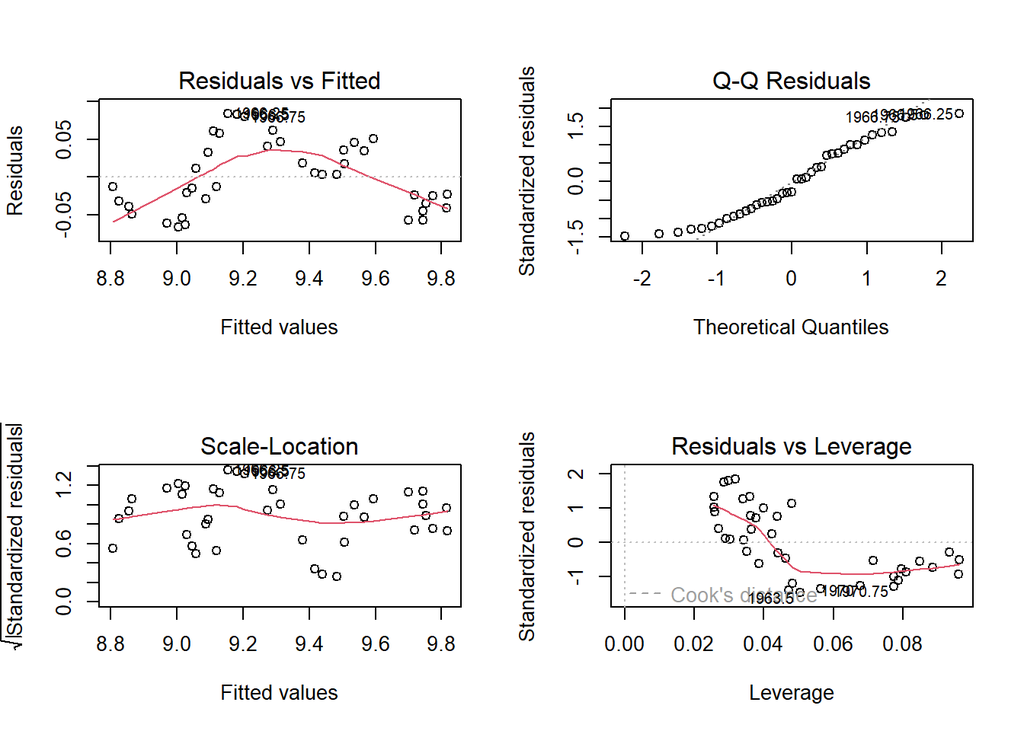

```r
par(mfrow = c(2, 2))
plot(modelo1)
```

Podemos ver en el Q-Q plot que los residuos no parecen ajustarse a un normal, vamos a comprobar con el test de Shapiro-Wilk si podemos rechazar la hipótesis nula de que los residuos siguen una distribución normal.

```r
print(paste0("Los residuos tienen media: ",round(mean(res1),4)))
```

```
## [1] "Los residuos tienen media: 0"
```

```r
shapiro.test(res1)
```

```
##
##  Shapiro-Wilk normality test
##
## data:  res1
## W = 0.94298, p-value = 0.04781
```

Vemos que el $p-value$ es $0.04781$ que es menor a $0.05$, por lo que podemos rechazar la hipótesis nula de que los residuos siguen una distribución normal. Como nuestro problema tiene una cantidad de observaciones elevada, debido al teorema central del límite, podemos dejar pasar por alto este supuesto.

Vamos a comprobar si existe heterocedasticidad en los residuos, es decir, si la varianza de los residuos es constante. Para ello, utilizaremos el test de Breusch-Pagan, que nos permite ver si la varianza de los residuos es constante.

```r
bptest(modelo1)
```

```
##
##  studentized Breusch-Pagan test
##
## data:  modelo1
## BP = 1.1962, df = 1, p-value = 0.2741
```

El $p-value$ es $0.2741$, por lo que no podemos rechazar la hipótesis nula de que la varianza de los residuos es constante. Por lo que podemos decir que no hay heterocedasticidad en los residuos.

Para comprobar si los residuos son independientes, utilizaremos el test de Durbin-Watson, que nos permite ver si hay autocorrelación en los residuos.

```r
durbinWatsonTest(modelo1)
```

```
##  lag Autocorrelation D-W Statistic p-value
##    1       0.8218003     0.3473076       0
##  Alternative hypothesis: rho != 0
```

El valor de Durbin-Watson es $0.3473076$, que está lejos de $2$, por lo que podemos decir que los residuos estan correlacionados, esto incumple uno de los supuestos básicos del modelo. En nuestro conjunto de datos esto no sorprende, ya que los valores de ventas de un trimestre dependen directamente del trimestre anterior. Esto indica que aunque el $R^2$ sea alto, el modelo no es el más adecuado para predecir las ventas o que debemos realizar transformaciones en las variables.

### 1.5 Realizar el contraste de si la relación entre precios y ventas de freeny es negativa con un nivel de significación del 0.05

Para realizar el contraste de si la relación entre precios y ventas de freeny es negativa, utilizaremos el test de hipótesis. La hipótesis nula es que la relación entre precios y ventas de freeny es positiva, y la hipótesis alternativa es que la relación entre precios y ventas de freeny es negativa.

Es decir $H_0 : \beta_{price.index}\geq 0$ y $H_1 : \beta_{price.index}< 0$ , si el $p-value < 0.05 $ podemos rechazar la hipotesis nula y aceptar la hipotesis alternativa.

```r
summary(modelo1)
```

```
##
## Call:
## lm(formula = y ~ price.index, data = freeny)
##
## Residuals:
##      Min       1Q   Median       3Q      Max
## -0.06666 -0.03696 -0.01259  0.03773  0.08382
##
## Coefficients:
##             Estimate Std. Error t value Pr(>|t|)
## (Intercept)  19.8359     0.2528   78.46   <2e-16 ***
## price.index  -2.3419     0.0562  -41.67   <2e-16 ***
## ---
## Signif. codes:  0 '***' 0.001 '**' 0.01 '*' 0.05 '.' 0.1 ' ' 1
##
## Residual standard error: 0.0462 on 37 degrees of freedom
## Multiple R-squared:  0.9791, Adjusted R-squared:  0.9786
## F-statistic:  1736 on 1 and 37 DF,  p-value: < 2.2e-16
```

Podemos ver que el $p-value$ es $< 2.2e-16$, pero nuestro modelo evalua ambas colas, ya que supone normalidad, para analizar solo una de ellas debemos tomar la mitad del $p-value$.

```r
p_value2 <- summary(modelo1)$coefficients[2,4]/2
print(paste0("El p-value unilateral corresponde a: ",p_value2))
```

```
## [1] "El p-value unilateral corresponde a: 5.34531498450355e-33"
```

Esto implica que podemos rechazar la hipotesis nula y aceptar la hipotesis alternativa, es decir, que la relación entre precios y ventas de freeny es negativa. De cualquier forma, el análisis de los residuos nos indica que el modelo no es el más adecuado para predecir las ventas, por lo que quizá con otro modelo encontramos otra evicendia.

## 2. Regresión múltiple

### 2.1 Estimar el mejor modelo de regresión multiple.

Para realizar el mejor modelo de regresión multiple podemos utilizar varios métodos, como el método de selección de variables hacia adelante, hacia atrás, o el método de selección de variables por pasos. En este caso, utilizaremos el método de selección de variables por pasos, que nos permite seleccionar las variables más significativas para el modelo. Para realizar este modelo, necesitamos definir un criterio de selección, en este caso utilizaremos el criterio de Akaike (AIC).

Contruimos primero el modelo completo, y luego utilizamos la función step para seleccionar las variables más significativas.

```r
modelo_full <- lm(y ~ lag.quarterly.revenue + price.index + income.level + market.potential, data = freeny)
summary(modelo_full)
```

```
##
## Call:
## lm(formula = y ~ lag.quarterly.revenue + price.index + income.level +
##     market.potential, data = freeny)
##
## Residuals:
##        Min         1Q     Median         3Q        Max
## -0.0259426 -0.0101033  0.0003824  0.0103236  0.0267124
##
## Coefficients:
##                       Estimate Std. Error t value Pr(>|t|)
## (Intercept)           -10.4726     6.0217  -1.739   0.0911 .
## lag.quarterly.revenue   0.1239     0.1424   0.870   0.3904
## price.index            -0.7542     0.1607  -4.693 4.28e-05 ***
## income.level            0.7675     0.1339   5.730 1.93e-06 ***
## market.potential        1.3306     0.5093   2.613   0.0133 *
## ---
## Signif. codes:  0 '***' 0.001 '**' 0.01 '*' 0.05 '.' 0.1 ' ' 1
##
## Residual standard error: 0.01473 on 34 degrees of freedom
## Multiple R-squared:  0.9981, Adjusted R-squared:  0.9978
## F-statistic:  4354 on 4 and 34 DF,  p-value: < 2.2e-16
```

Podemos ver que el modelo seleccionado es el siguiente:

```r
modelo_optimo <- step(modelo_full, direction = "both")
```

```
## Start:  AIC=-324.36
## y ~ lag.quarterly.revenue + price.index + income.level + market.potential
##
##                         Df Sum of Sq       RSS     AIC
## - lag.quarterly.revenue  1 0.0001642 0.0075392 -325.50
## <none>                               0.0073750 -324.36
## - market.potential       1 0.0014805 0.0088555 -319.22
## - price.index            1 0.0047767 0.0121517 -306.88
## - income.level           1 0.0071230 0.0144980 -299.99
##
## Step:  AIC=-325.5
## y ~ price.index + income.level + market.potential
##
##                         Df Sum of Sq       RSS     AIC
## <none>                               0.0075392 -325.50
## + lag.quarterly.revenue  1 0.0001642 0.0073750 -324.36
## - market.potential       1 0.0040174 0.0115565 -310.84
## - price.index            1 0.0087700 0.0163092 -297.40
## - income.level           1 0.0157017 0.0232409 -283.59
```

```r
summary(modelo_optimo)
```

```
##
## Call:
## lm(formula = y ~ price.index + income.level + market.potential,
##     data = freeny)
##
## Residuals:
##        Min         1Q     Median         3Q        Max
## -0.0273061 -0.0090031  0.0007218  0.0111354  0.0270294
##
## Coefficients:
##                   Estimate Std. Error t value Pr(>|t|)
## (Intercept)      -13.31014    5.04423  -2.639 0.012339 *
## price.index       -0.83488    0.13084  -6.381 2.44e-07 ***
## income.level       0.84556    0.09904   8.538 4.47e-10 ***
## market.potential   1.62735    0.37682   4.319 0.000123 ***
## ---
## Signif. codes:  0 '***' 0.001 '**' 0.01 '*' 0.05 '.' 0.1 ' ' 1
##
## Residual standard error: 0.01468 on 35 degrees of freedom
## Multiple R-squared:  0.998,  Adjusted R-squared:  0.9978
## F-statistic:  5846 on 3 and 35 DF,  p-value: < 2.2e-16
```

Tenemos un R cuadrado de 0.998 y un R cuadarado ajustado de 0.997, lo que significa que el modelo se ajusta muy bien a los datos. Además, el p-valor de las variables es muy bajo, lo que significa que las variables son significativas. Podemos ver los gráficos de los residuos y realizar los test de normalidad, heterocedasticidad y autocorrelación, como realizamos en el modelo anterior.

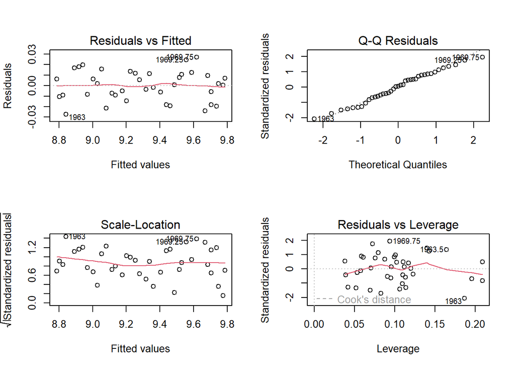

```r
par(mfrow = c(2,2))
plot(modelo_optimo)
```

En los gráficos podemos apreciar que los residuos siguen una distribución normal, la varianza de los residuos es constante y no hay autocorrelación en los residuos. Realizaremos los test pertinentes ya que graficamente puede no ser 100% fiable.

```r
r_sq2 <- summary(modelo_optimo)$r.squared
res2 <- residuals(modelo_optimo)
print(paste0("Los residuos tienen media: ",round(mean(res2),4)))
```

```
## [1] "Los residuos tienen media: 0"
```

```r
shapiro.test(res2)
```

```
##
##  Shapiro-Wilk normality test
##
## data:  res2
## W = 0.97814, p-value = 0.636
```

El test de Shapiro-Wilk nos da un $p-value$ de $0.636$, por lo que no podemos rechazar la hipótesis nula de que los residuos siguen una distribución normal. Es decir, los residuos siguen una distribución normal.

```r
bptest(modelo_optimo)
```

```
##
##  studentized Breusch-Pagan test
##
## data:  modelo_optimo
## BP = 3.9647, df = 3, p-value = 0.2653
```

El test de Breusch-Pagan nos da un $p-value$ de $0.2653$, por lo que no podemos rechazar la hipótesis nula de que la varianza de los residuos es constante. Es decir, la varianza de los residuos es constante (homocedasticidad).

```r
durbinWatsonTest(modelo_optimo)
```

```
##  lag Autocorrelation D-W Statistic p-value
##    1       0.1606572      1.667245     0.1
##  Alternative hypothesis: rho != 0
```

El valor de Durbin-Watson es $1.667245$, que está cerca de $2$, por lo que podemos decir que los residuos no están fuertemente correlacionados.

A diferencia del modelo anterior, no solo tenemos un valor bueno del $R^2$ y $R^2$ ajustado, sino que los residuos cumplen con los supuestos básicos del modelo, por lo que este modelo es mejor que el anterior.

### 2.2 Mejora el modelo utilizando GLM

Para mejorar el modelo utilizando GLM, utilizaremos la función glm, que nos permite ajustar un modelo lineal generalizado. En este caso, utilizaremos la familia de distribución gaussiana, ya que estamos trabajando con una variable continua.

```r
modelo_glm_full <- glm(y ~ lag.quarterly.revenue + price.index + income.level + market.potential, data = freeny, family = gaussian())
modelo_nulo <- glm(y ~ 1, data=freeny, family=gaussian())

modelo_glm <- step(modelo_glm_full, direction = "both")
```

```
## Start:  AIC=-211.68
## y ~ lag.quarterly.revenue + price.index + income.level + market.potential
##
##                         Df  Deviance     AIC
## - lag.quarterly.revenue  1 0.0075392 -212.82
## <none>                     0.0073750 -211.68
## - market.potential       1 0.0088555 -206.54
## - price.index            1 0.0121517 -194.20
## - income.level           1 0.0144980 -187.32
##
## Step:  AIC=-212.82
## y ~ price.index + income.level + market.potential
##
##                         Df  Deviance     AIC
## <none>                     0.0075392 -212.82
## + lag.quarterly.revenue  1 0.0073750 -211.68
## - market.potential       1 0.0115565 -198.16
## - price.index            1 0.0163092 -184.73
## - income.level           1 0.0232409 -170.91
```

```r
pseudoR2 <- 1 - (modelo_glm$deviance / modelo_nulo$deviance)
cat("\n")
```

```r
print(paste0("El pseudo R cuadrado es: ",pseudoR2))
```

```
## [1] "El pseudo R cuadrado es: 0.99800832293476"
```

```r
summary(modelo_glm)
```

```
##
## Call:
## glm(formula = y ~ price.index + income.level + market.potential,
##     family = gaussian(), data = freeny)
##
## Coefficients:
##                   Estimate Std. Error t value Pr(>|t|)
## (Intercept)      -13.31014    5.04423  -2.639 0.012339 *
## price.index       -0.83488    0.13084  -6.381 2.44e-07 ***
## income.level       0.84556    0.09904   8.538 4.47e-10 ***
## market.potential   1.62735    0.37682   4.319 0.000123 ***
## ---
## Signif. codes:  0 '***' 0.001 '**' 0.01 '*' 0.05 '.' 0.1 ' ' 1
##
## (Dispersion parameter for gaussian family taken to be 0.0002154044)
##
##     Null deviance: 3.7853294  on 38  degrees of freedom
## Residual deviance: 0.0075392  on 35  degrees of freedom
## AIC: -212.82
##
## Number of Fisher Scoring iterations: 2
```

Hemos utilizado el método step otra vez midiendo el AIC, tenemos un modelo que relaciona price.index, income.level y market.potential con las ventas de freeny. Podemos ver que el modelo se ajusta muy bien a los datos, ya que el pseudo $R^2$ es $0.998$, en el modelo anterior tenemos un $R^2$ de $0.998$, por lo que ambos modelos se ajustan muy bien a los datos.

### 2.3 Estime el mismo por un procedimiento Bayesiano, y indique si este método de estimación mejora los resultados de los anteriores métodos.

```r
modelo_bayes <- stan_glm(y ~ price.index + income.level + market.potential,
                         data = freeny,
                         family = gaussian(),
                         seed = seed)
```

```r
summary(modelo_bayes)
```

```
##
## Model Info:
##  function:     stan_glm
##  family:       gaussian [identity]
##  formula:      y ~ price.index + income.level + market.potential
##  algorithm:    sampling
##  sample:       4000 (posterior sample size)
##  priors:       see help('prior_summary')
##  observations: 39
##  predictors:   4
##
## Estimates:
##                    mean   sd    10%   50%   90%
## (Intercept)      -13.2    5.4 -20.0 -13.2  -6.4
## price.index       -0.8    0.1  -1.0  -0.8  -0.7
## income.level       0.8    0.1   0.7   0.8   1.0
## market.potential   1.6    0.4   1.1   1.6   2.1
## sigma              0.0    0.0   0.0   0.0   0.0
##
## Fit Diagnostics:
##            mean   sd   10%   50%   90%
## mean_PPD 9.3    0.0  9.3   9.3   9.3
##
## The mean_ppd is the sample average posterior predictive distribution of the outcome variable (for details see help('summary.stanreg')).
##
## MCMC diagnostics
##                  mcse Rhat n_eff
## (Intercept)      0.2  1.0  1212
## price.index      0.0  1.0  1408
## income.level     0.0  1.0  1451
## market.potential 0.0  1.0  1183
## sigma            0.0  1.0  1633
## mean_PPD         0.0  1.0  3749
## log-posterior    0.1  1.0  1174
##
## For each parameter, mcse is Monte Carlo standard error, n_eff is a crude measure of effective sample size, and Rhat is the potential scale reduction factor on split chains (at convergence Rhat=1).
```

Vamos a obtener el WAIC, que es la versión de AIC para modelos bayesianos, y nos permite comparar modelos bayesianos. Cuanto menor sea el WAIC, mejor será el modelo.

```r
loo_bayes <- waic(modelo_bayes)
print(waic(modelo_bayes))
```

```
##
## Computed from 4000 by 39 log-likelihood matrix.
##
##           Estimate  SE
## elpd_waic    106.1 3.4
## p_waic         4.5 0.9
## waic        -212.1 6.8
##
## 1 (2.6%) p_waic estimates greater than 0.4. We recommend trying loo instead.
```

### 2.4 Calcule las distancias de cook, si lo considera conveniente realice una estimación robusta. Justifique su decisión.

Para calcular las distancias de cook, utilizaremos la función cooks.distance, que nos permite calcular las distancias de cook. Las distancias de cook nos permiten ver la influencia de cada observación en el modelo. Si la distancia de cook es mayor a 1, la observación es influyente, y si la distancia de cook es mayor a 4/n, la observación es muy influyente.

```r
# Distancias de Cook
cooks_dist <- cooks.distance(modelo_optimo)
round(cooks_dist, 4)
```

```
## 1962.25  1962.5 1962.75    1963 1963.25  1963.5 1963.75    1964 1964.25  1964.5
##  0.0148  0.0438  0.0292  0.2442  0.0639  0.0884  0.0850  0.0111  0.0058  0.0007
## 1964.75    1965 1965.25  1965.5 1965.75    1966 1966.25  1966.5 1966.75    1967
##  0.0272  0.0423  0.0068  0.0106  0.0047  0.0331  0.0267  0.0198  0.0052  0.0010
## 1967.25  1967.5 1967.75    1968 1968.25  1968.5 1968.75    1969 1969.25  1969.5
##  0.0106  0.0003  0.0019  0.0177  0.0248  0.0000  0.0028  0.0120  0.0591  0.0119
## 1969.75    1970 1970.25  1970.5 1970.75    1971 1971.25  1971.5 1971.75
##  0.0970  0.0665  0.0114  0.0055  0.0550  0.0602  0.0004  0.0000  0.0077
```

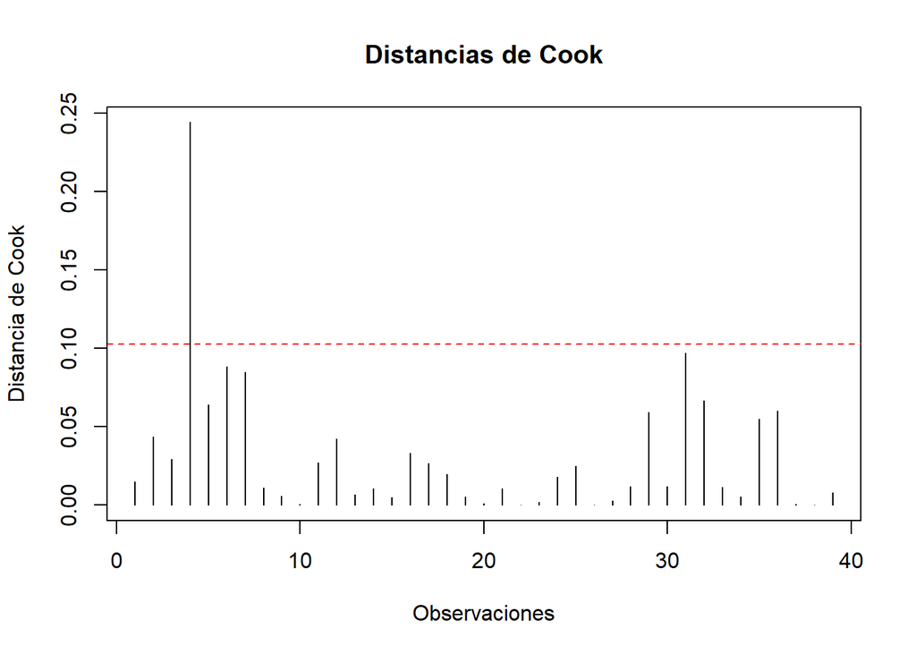

```r
plot(cooks_dist, type="h",
     main="Distancias de Cook",
     ylab="Distancia de Cook",
     xlab="Observaciones")
abline(h=4/nrow(freeny), col="red", lty=2) # Umbral para observaciones muy influyentes
abline(h=1, col="blue", lty=2)
```

Como hay una observación que supera el umbral de 4/n, vamos a realizar una estimación robusta utilizando la función rlm, que nos permite ajustar un modelo lineal robusto.

```r
modelo_robusto <- rlm(y ~ price.index + income.level + market.potential, data=freeny)
summary(modelo_robusto)
```

```
##
## Call: rlm(formula = y ~ price.index + income.level + market.potential,
##     data = freeny)
## Residuals:
##       Min        1Q    Median        3Q       Max
## -0.028036 -0.009359  0.001024  0.011400  0.027406
##
## Coefficients:
##                  Value    Std. Error t value
## (Intercept)      -13.2822   5.3928    -2.4630
## price.index       -0.8373   0.1399    -5.9856
## income.level       0.8387   0.1059     7.9212
## market.potential   1.6292   0.4029     4.0441
##
## Residual standard error: 0.01644 on 35 degrees of freedom
```

Vamos a comparar los coeficientes de ambos modelos.

```r
summary(modelo_glm)$coefficients
```

```
##                     Estimate Std. Error   t value     Pr(>|t|)
## (Intercept)      -13.3101438 5.04422672 -2.638689 1.233932e-02
## price.index       -0.8348827 0.13084368 -6.380764 2.440745e-07
## income.level       0.8455586 0.09903694  8.537810 4.468975e-10
## market.potential   1.6273453 0.37682203  4.318605 1.230439e-04
```

La estabilidad entre ambos modelos confirma la fiabilidad del modelo robusto, en el que hemos evitado la influyencia elevada de una de las observaciones.

### 2.5 A la vista de las variables explicativas cree que sería más adecuado estimar el modelo utilizando la regresión ridge o el mínimo cuadrado ordinario. En caso afirmativo estime el modelo y analice sus resultados.

El modelo ridge es un modelo de regresión lineal que utiliza la regularización L2, que nos permite reducir la complejidad del modelo y evitar el sobreajuste. Es adeacuado cuando tenemos multicolinealidad en las variables explicativas, ya que reduce la varianza de los coeficientes. Para ver si es conveniente utilizar este modelo, podemos comprobar la multicolinealidad de las variables explicativas utilizando la función vif, que nos permite ver el factor de inflación de la varianza de las variables explicativas.

```r
vif(modelo_glm)
```

```
##      price.index     income.level market.potential
##         53.71126         25.10082        104.22550
```

Como estamos obteniendo valores muy altos de VIF, podemos decir que hay multicolinealidad en las variables explicativas, por lo que sería más adecuado estimar el modelo utilizando la regresión ridge. Para estimar el modelo utilizando la regresión ridge, utilizaremos la función glmnet, que nos permite ajustar un modelo de regresión ridge.

```r
X <- model.matrix(y ~ price.index + income.level + market.potential, data=freeny)[,-1]
y <- as.numeric(freeny$y)

# Estimación del modelo Ridge (alpha=0 para Ridge)
set.seed(seed)
modelo_ridge <- cv.glmnet(X, y, alpha=0)

coef(modelo_ridge, s="lambda.min")
```

```
## 4 x 1 sparse Matrix of class "dgCMatrix"
##                           s1
## (Intercept)      -13.1002523
## price.index       -0.7801045
## income.level       0.8366051
## market.potential   1.5965714
```

Vemos que los coeficientes son muy similares a los del modelo GLM, disminuyendo sus valores, por lo que se puede apreciar la penalización de la regularización L2 para reducir la varianza. Podemos calcular el $R^2$ del modelo ridge para ver si mejora el modelo GLM.

```r
pred_ridge <- predict(modelo_ridge, s = "lambda.min", newx = X)
SSE <- sum((y - pred_ridge)^2)
SST <- sum((y - mean(y))^2)

R2_ridge <- 1 - (SSE / SST)
R2_ridge
```

```
## [1] 0.9969406
```

Obtenemos un $R^2$ de $0.996$, muy similar al modelo GLM aunque menor. La diferencia no es sustancial.

## 3. Estimar modelo que relacione el precio de freeny con las ventas de freeny, utilizando polinomios.

Vamos a realizar el modelo polinómico de grado 2 y grado 3 los compararemos.

```r
# Ajustar modelo polinómico grado 2
modelo_poly2 <- lm(y ~ poly(price.index, 2, raw=TRUE), data=freeny)
summary(modelo_poly2)
```

```
##
## Call:
## lm(formula = y ~ poly(price.index, 2, raw = TRUE), data = freeny)
##
## Residuals:
##       Min        1Q    Median        3Q       Max
## -0.063975 -0.025721  0.004016  0.025777  0.060419
##
## Coefficients:
##                                   Estimate Std. Error t value Pr(>|t|)
## (Intercept)                       -20.7470     7.5007  -2.766   0.0089 **
## poly(price.index, 2, raw = TRUE)1  15.7737     3.3474   4.712 3.61e-05 ***
## poly(price.index, 2, raw = TRUE)2  -2.0199     0.3732  -5.412 4.24e-06 ***
## ---
## Signif. codes:  0 '***' 0.001 '**' 0.01 '*' 0.05 '.' 0.1 ' ' 1
##
## Residual standard error: 0.03478 on 36 degrees of freedom
## Multiple R-squared:  0.9885, Adjusted R-squared:  0.9879
## F-statistic:  1547 on 2 and 36 DF,  p-value: < 2.2e-16
```

```r
# Modelo polinómico grado 3
modelo_poly3 <- lm(y ~ poly(price.index, 3, raw=TRUE), data=freeny)
summary(modelo_poly3)
```

```
##
## Call:
## lm(formula = y ~ poly(price.index, 3, raw = TRUE), data = freeny)
##
## Residuals:
##       Min        1Q    Median        3Q       Max
## -0.059841 -0.028263  0.004398  0.021318  0.064119
##
## Coefficients:
##                                   Estimate Std. Error t value Pr(>|t|)
## (Intercept)                       -263.147    282.850  -0.930    0.359
## poly(price.index, 3, raw = TRUE)1  177.751    188.970   0.941    0.353
## poly(price.index, 3, raw = TRUE)2  -38.080     42.065  -0.905    0.372
## poly(price.index, 3, raw = TRUE)3    2.675      3.120   0.857    0.397
##
## Residual standard error: 0.03491 on 35 degrees of freedom
## Multiple R-squared:  0.9887, Adjusted R-squared:  0.9878
## F-statistic:  1024 on 3 and 35 DF,  p-value: < 2.2e-16
```

Podemos ver como el R cuadrado ajustado es muy similar en ambos casos, pero el P-value de lso coeficientes del modelo de grado 3 indica que no son significativos, por lo que el modelo de grado 2 es claramente mejor.

Analizaremos el modelo polinomial de grado 2.

```r
summary(modelo_poly2)
```

```
##
## Call:
## lm(formula = y ~ poly(price.index, 2, raw = TRUE), data = freeny)
##
## Residuals:
##       Min        1Q    Median        3Q       Max
## -0.063975 -0.025721  0.004016  0.025777  0.060419
##
## Coefficients:
##                                   Estimate Std. Error t value Pr(>|t|)
## (Intercept)                       -20.7470     7.5007  -2.766   0.0089 **
## poly(price.index, 2, raw = TRUE)1  15.7737     3.3474   4.712 3.61e-05 ***
## poly(price.index, 2, raw = TRUE)2  -2.0199     0.3732  -5.412 4.24e-06 ***
## ---
## Signif. codes:  0 '***' 0.001 '**' 0.01 '*' 0.05 '.' 0.1 ' ' 1
##
## Residual standard error: 0.03478 on 36 degrees of freedom
## Multiple R-squared:  0.9885, Adjusted R-squared:  0.9879
## F-statistic:  1547 on 2 and 36 DF,  p-value: < 2.2e-16
```

Podemos ver como el intercepto es negativo y, esto quiere decir que potencialmente si el precio fuse 0, las ventas serían 0 (ya que no tiene sentido promedio de ventas -20). El coeficiente lineal nos indica que segun aumenta el precio las ventas aumentan considerablemente. Y el coeficiente cuadrático nos indica que la relación no es lineal, que llega un punto de la subida de precios que puede estancar las ventas y llegar a disminuirlas.

```r
summary(modelo_poly2)$r.squared
```

```
## [1] 0.9884951
```

Tenemos un $R^2$ de 0.98 que es menor que el obtenido con el modelo GLM. Veamos los gráficos del modelo

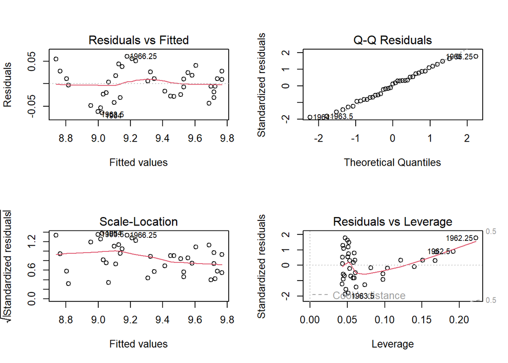

```r
par(mfrow=c(2,2))
plot(modelo_poly2)
```

Podemos ver como los residuos siguen una distribución se ajustan a una distribución normal, la varianza parece constante entre 1 y 0.8, por lo que parece indicar que no hay heterocedasticidad, y el gráfico de la distancia de Cook vemos como no hay ninguna observación influyente.

## 4. Cree una variable temporal relativa al año y otra relativa al trimestre. Realice un modelo ANOVA para las ventas utilizando el año y el trimestre, estime un modelo de ancova utilizando el precio como covariable.Comente los resultados.

Para el modelo ANOVA, necesitamos hacer la transformación en el tiempo, para ello vamos a crear dos variables, una relativa al año y otra relativa al trimestre. Para ello, utilizaremos la función factor, que nos permite crear una variable categórica.

```r
freeny <- freeny %>%
  mutate(Date = as.numeric(rownames(.))) %>%
  mutate(Year = floor(Date),
         Quarter = (Date - Year) * 4 + 1)

freeny$Year <- factor(freeny$Year)
freeny$Quarter <- factor(freeny$Quarter)

anova_model <- aov(y ~ Year + Quarter, data=freeny)
summary(anova_model)
```

```
##             Df Sum Sq Mean Sq F value   Pr(>F)
## Year         9  3.733  0.4148 1777.32  < 2e-16 ***
## Quarter      3  0.046  0.0153   65.43 3.03e-12 ***
## Residuals   26  0.006  0.0002
## ---
## Signif. codes:  0 '***' 0.001 '**' 0.01 '*' 0.05 '.' 0.1 ' ' 1
```

Ambas variables son claramente significativas, por lo que podemos decir que el año y el trimestre influyen en las ventas.

Vamos a realizar ahora el modelo ANCOVA utilizando el precio como covariable.

```r
modelo_ancova <- lm(y ~ Year + Quarter + price.index, data=freeny)

summary(modelo_ancova)
```

```
##
## Call:
## lm(formula = y ~ Year + Quarter + price.index, data = freeny)
##
## Residuals:
##        Min         1Q     Median         3Q        Max
## -0.0304794 -0.0054657  0.0009221  0.0071827  0.0226972
##
## Coefficients:
##              Estimate Std. Error t value Pr(>|t|)
## (Intercept) 12.857989   1.404834   9.153 1.86e-09 ***
## Year1963     0.067515   0.021523   3.137  0.00434 **
## Year1964     0.151407   0.030405   4.980 3.93e-05 ***
## Year1965     0.226412   0.038086   5.945 3.32e-06 ***
## Year1966     0.329875   0.046060   7.162 1.66e-07 ***
## Year1967     0.386917   0.064241   6.023 2.72e-06 ***
## Year1968     0.445363   0.082833   5.377 1.41e-05 ***
## Year1969     0.535129   0.094042   5.690 6.32e-06 ***
## Year1970     0.558629   0.116374   4.800 6.25e-05 ***
## Year1971     0.613070   0.124377   4.929 4.48e-05 ***
## Quarter2     0.037143   0.007362   5.045 3.32e-05 ***
## Quarter3     0.048324   0.009330   5.180 2.34e-05 ***
## Quarter4     0.068111   0.011476   5.935 3.40e-06 ***
## price.index -0.874296   0.297405  -2.940  0.00698 **
## ---
## Signif. codes:  0 '***' 0.001 '**' 0.01 '*' 0.05 '.' 0.1 ' ' 1
##
## Residual standard error: 0.01343 on 25 degrees of freedom
## Multiple R-squared:  0.9988, Adjusted R-squared:  0.9982
## F-statistic:  1612 on 13 and 25 DF,  p-value: < 2.2e-16
```

```r
anova(modelo_ancova)
```

```
## Analysis of Variance Table
##
## Response: y
##             Df Sum Sq Mean Sq   F value    Pr(>F)
## Year         9 3.7334 0.41483 2299.7231 < 2.2e-16 ***
## Quarter      3 0.0458 0.01527   84.6655 3.155e-13 ***
## price.index  1 0.0016 0.00156    8.6421  0.006975 **
## Residuals   25 0.0045 0.00018
## ---
## Signif. codes:  0 '***' 0.001 '**' 0.01 '*' 0.05 '.' 0.1 ' ' 1
```

Parece que todas las variables son significativas, el valor del $R^2$ ajustado es $0.99$, por lo que el modelo parece tener una gran capacidad predictiva. Analicemos ahora los residuos para comprobar si cumplen con los criterios.

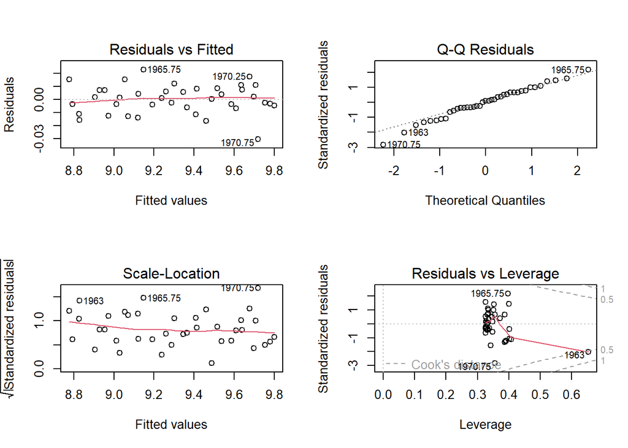

```r
par(mfrow=c(2,2))
plot(modelo_ancova)
```

```r
res_anco <- residuals(modelo_ancova)
print(paste0("Los residuos tienen media: ",round(mean(res_anco),4)))
```

```
## [1] "Los residuos tienen media: 0"
```

```r
shapiro.test(res_anco)
```

```
##
##  Shapiro-Wilk normality test
##
## data:  res_anco
## W = 0.98413, p-value = 0.8464
```

El test de Shapiro-Wilk nos da un $p-value$ de $0.8464$, por lo que no podemos rechazar la hipótesis nula de que los residuos siguen una distribución normal. Es decir, los residuos siguen una distribución normal.

```r
ncvTest(modelo_ancova)
```

```
## Non-constant Variance Score Test
## Variance formula: ~ fitted.values
## Chisquare = 0.08789908, Df = 1, p = 0.76687
```

El test de Non-constant Variance Score Test nos da un $p-value$ de $0.76687$, por lo que no podemos rechazar la hipótesis nula de que la varianza de los residuos es constante. Es decir, la varianza de los residuos es constante (homocedasticidad).

```r
durbinWatsonTest(modelo_ancova)
```

```
##  lag Autocorrelation D-W Statistic p-value
##    1     -0.03999292        2.0241   0.176
##  Alternative hypothesis: rho != 0
```

El valor de Durbin-Watson es $2.0241$, que está cerca de $2$, por lo que podemos decir que los residuos no están fuertemente correlacionados.

Es decir, los test nos confirman que se cumplen los supuestos básicos del modelo, por lo que el modelo ANCOVA es adecuado para predecir las ventas.